# MaxDiff assesment

Niranjan Poudel

6/23/2021

### Some intresting summary and notes from the analysis

- Includes the count analysis which gives best worst scales and logit modeling.
- In the modeling analysis **Message 15** (Flexible dosing) is used as base/reference study (Can be chosen anyone, just to make all the estimates positive).
- **For the purpose of random parameter estimates only 10 draws are taken for economic computation.**
1. **Message 4** (Efficacy in high baseline VL) is the relatively most preferred option.
2. **Message 15** (Flexible dosing) is relatively least preferred option. (**Message 16** as well)
3. Some of the other relatively more preferred messages are **Message 6** (Efficacy comparison (vs efavirezen)) and **Message 5** (Efficacy comparison (vs darunavir))
4. Physicians are comparatively more neutral to **Message 2** (Resistance rate comparison) and **Message 8** (Managing patients with HIV and hyperlipidemia)
5. Relatively high degree of variance is observed in **Message 1** (Efficacy in presence of NNRTI resistance mutations), **Message 8** (Managing patients with HIV and hyperlipidemia).
6. While fewer differences are observed based on the type of physicians relative differences can be observed for Canadian Physician compared to Mexican Physicians.
- There is some issue with the newest version of mlogit especially while estimating a latent class model using gmnl function of gmnl package so here we download a older version of the package instead.

```r
install.packages("https://cran.r-project.org/src/contrib/Archive/mlogit/mlogit_1.0-2.tar.gz", repos=NULL,type="source")
```

Loading the packages required for analysis

```r
library(readxl)
library(tidyverse)
library(support.BWS)
library(crossdes)
library(dfidx)
library(mlogit)
library(gmnl)
```

Reading the data set and checking to see if there are any missing values

```r
Data <- read_excel("C:/Users/Niranjan.p/Desktop/I market problem/Copy of Assessment Data v1(8166).xlsx")
sum(is.na(Data))
```

```
## [1] 0
```

Even though the slot of the messages are different, the design seems to be same for all individuals. Generating the design matrix which is required by the package (support.BWS) we are going to use.

```r
## Taking the design from the slot of first respondent
Data %>%
  .[1:12,] %>%
  select(Slot_1: Slot_8) %>%
  rename_with(~gsub("Slot_","V", .)) %>%
  as.matrix(.) -> Design
```

Making a wide data (one row per individual) which includes most preferred and least preferred choices.

```r
Data %>%
  rename(b = Most_Appealing_Message ) %>%
  rename(w = Least_Appealing_Message) %>%
  pivot_wider(id_cols = c("Respondent","Physician_Type", "Country"),
                names_from = SETID, values_from = c("b", "w")) %>%
  rename_with(~   gsub("_", "", .)) %>%
  as.data.frame(.)-> Response
```

Rearranging- just to make it simple to use with the package.

```r
Response <- Response[,c(1,4,16, 5, 17, 6, 18, 7, 19,8,20,
                        9,21, 10,22, 11,23, 12,24, 13,25,
                        14,26, 15, 27, 2,3)]
```

Vectors of some names required for preparing the data in suitable format.

```r
# M relates to respective messages
response.vars <- colnames(Response)[2:25]
item.message <- c("M1","M2","M3","M4","M5","M6","M7","M8",
             "M9","M10", "M11", "M12","M13", "M14","M15", "M16")
```

Preparing the data as required by the package.

```r
md.data <- bws.dataset(
  data = Response,
  response.type = 2,
  choice.sets = Design,
  design.type = 2,
  item.names = item.message,
  id = "Respondent",
  response = response.vars,
  model = "maxdiff")
```

### First we will do count analysis, later followed by modelling analysis.

```r
## Running the analysis
cs <- bws.count(md.data, cl =2)
```

Plotting the BWS scores to visualize.

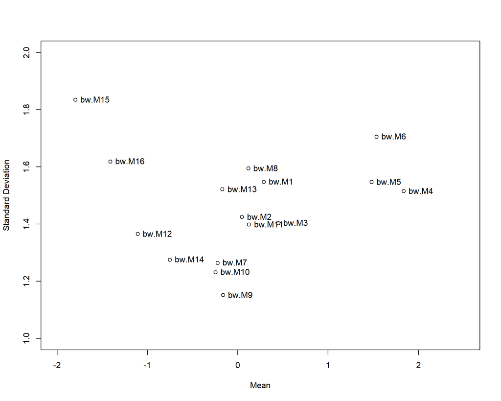

```r
plot(x =cs,
     score = "bw",
     pos =4,
     xlim = c(-2,2.5),
     ylim = c(1, 2))
```

Use of bar plots to visualize the heterogeneity.

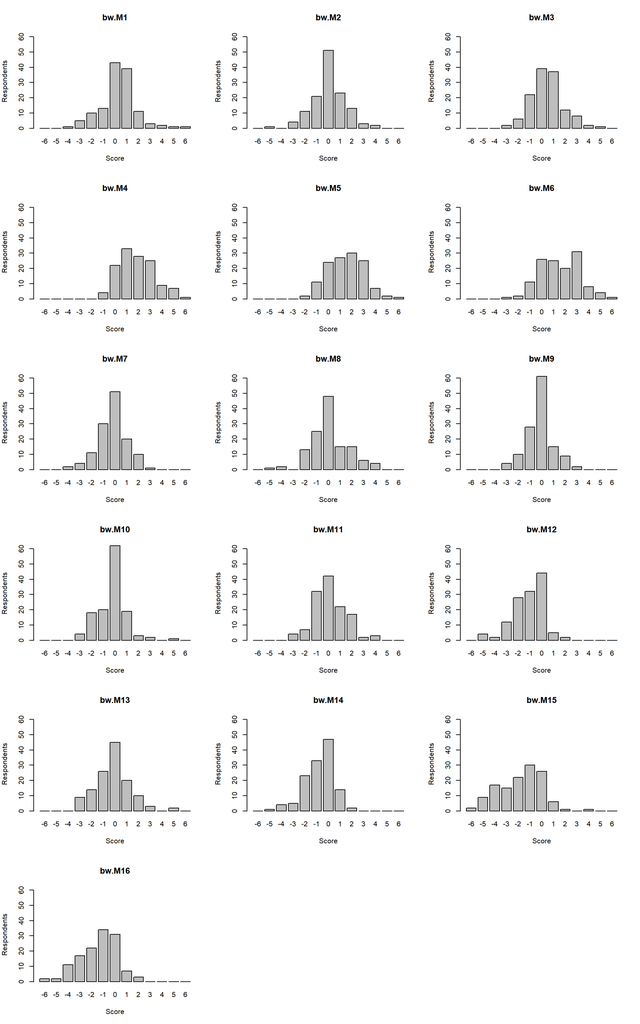

```r
par(mar = c(5, 4, 4, 2))
barplot(
  height = cs,
  score = "bw",
  mfrow = c(6, 3))
```

One more bar plot with order of preferences.

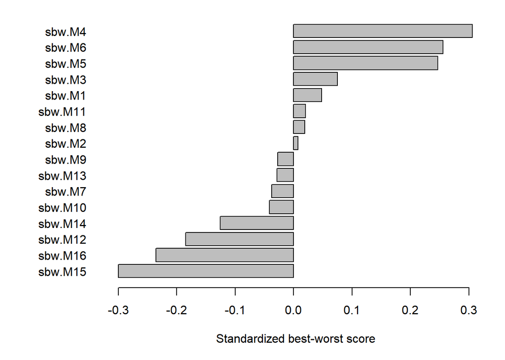

```r
par(mar = c(5, 7, 1, 1))
barplot(
  height = cs,
  score = "sbw", # Standardized BW scores are used
  mean = TRUE,   # Bar plot of mean scores is drawn
  las = 1)
```

```r
# M is respectuve message
```

Looking at overall sum and summary statistics

```r
sum(cs) # M is respectuve message
```

```
##       B   W   BW        stdBW
## M1  105  68   37  0.047803618
## M2   79  73    6  0.007751938
## M3  114  56   58  0.074935401
## M4  254  17  237  0.306201550
## M5  219  28  191  0.246770026
## M6  233  35  198  0.255813953
## M7   63  92  -29 -0.037467700
## M8   95  80   15  0.019379845
## M9   60  81  -21 -0.027131783
## M10  55  87  -32 -0.041343669
## M11  93  77   16  0.020671835
## M12  19 162 -143 -0.184754522
## M13  81 103  -22 -0.028423773
## M14  29 126  -97 -0.125322997
## M15  24 256 -232 -0.299741602
## M16  25 207 -182 -0.235142119
```

Summary

```r
summary(cs) # M is respectuve message
```

```
## Number of respondents = 129
##
##       B   W   BW Rank  meanB  meanW   meanBW mean.stdBW sqrtBW std.sqrtBW
## M1  105  68   37    5 0.8140 0.5271  0.28682   0.047804 1.2426    0.32148
## M2   79  73    6    8 0.6124 0.5659  0.04651   0.007752 1.0403    0.26913
## M3  114  56   58    4 0.8837 0.4341  0.44961   0.074935 1.4268    0.36912
## M4  254  17  237    1 1.9690 0.1318  1.83721   0.306202 3.8654    1.00000
## M5  219  28  191    3 1.6977 0.2171  1.48062   0.246770 2.7967    0.72352
## M6  233  35  198    2 1.8062 0.2713  1.53488   0.255814 2.5801    0.66750
## M7   63  92  -29   11 0.4884 0.7132 -0.22481  -0.037468 0.8275    0.21408
## M8   95  80   15    7 0.7364 0.6202  0.11628   0.019380 1.0897    0.28192
## M9   60  81  -21    9 0.4651 0.6279 -0.16279  -0.027132 0.8607    0.22266
## M10  55  87  -32   12 0.4264 0.6744 -0.24806  -0.041344 0.7951    0.20570
## M11  93  77   16    6 0.7209 0.5969  0.12403   0.020672 1.0990    0.28432
## M12  19 162 -143   14 0.1473 1.2558 -1.10853  -0.184755 0.3425    0.08860
## M13  81 103  -22   10 0.6279 0.7984 -0.17054  -0.028424 0.8868    0.22942
## M14  29 126  -97   13 0.2248 0.9767 -0.75194  -0.125323 0.4797    0.12411
## M15  24 256 -232   16 0.1860 1.9845 -1.79845  -0.299742 0.3062    0.07921
## M16  25 207 -182   15 0.1938 1.6047 -1.41085  -0.235142 0.3475    0.08991
```

### Modelling analysis (Conditional logit and random paramter mixed logit)

Simple conditional logit approach at first

## First making required dummy variables for future analysis

```r
md.data %>%
  mutate(Physician1 = ifelse(PhysicianType == 1, 1, 0)) %>%
  mutate(USA = ifelse(Country == 1, 1, 0)) %>%
  mutate(CANADA = ifelse(Country ==2, 1, 0)) -> md.dat
```

Preparing the dataset

```r
ml <- mlogit.data(data = md.dat, choice = "RES", shape = "long",
                  alt.var = "PAIR", chid.var = "STR", id.var = "Respondent")
```

Next, we make use of mlogit and gmnl package in R to model. Message 15 (M15) is used as base/reference alternative. (The selection is done just to keep all the estimates positive as M15 was the least preferred one from our count analysis).

```r
md.out <- mlogit::mlogit(formula = RES ~ M1 + M2 + M3 + M4 + M5 + M6 + M7 +M8 +
                   M9 + M10 + M11 + M12 + M13 + M14 + M16 -1,
                 data = ml, method = "nr")
summary(md.out)
```

```
##
## Call:
## mlogit::mlogit(formula = RES ~ M1 + M2 + M3 + M4 + M5 + M6 +
##     M7 + M8 + M9 + M10 + M11 + M12 + M13 + M14 + M16 - 1, data = ml,
##     method = "nr")
##
## Frequencies of alternatives:
##         1         2         3         4         5         6         7         8
## 0.0135659 0.0096899 0.0129199 0.0142119 0.0096899 0.0064599 0.0064599 0.0135659
##         9        10        11        12        13        14        15        16
## 0.0148579 0.0103359 0.0174419 0.0129199 0.0148579 0.0058140 0.0206718 0.0200258
##        17        18        19        20        21        22        23        24
## 0.0051680 0.0232558 0.0135659 0.0148579 0.0135659 0.0187339 0.0284238 0.0155039
##        25        26        27        28        29        30        31        32
## 0.0193798 0.0193798 0.0135659 0.0109819 0.0116279 0.0096899 0.0129199 0.0077519
##        33        34        35        36        37        38        39        40
## 0.0135659 0.0064599 0.0103359 0.0180879 0.0193798 0.0264858 0.0155039 0.0142119
##        41        42        43        44        45        46        47        48
## 0.0193798 0.0103359 0.0394057 0.0277778 0.0290698 0.0322997 0.0400517 0.0251938
##        49        50        51        52        53        54        55        56
## 0.0258398 0.0251938 0.0310078 0.0264858 0.0206718 0.0335917 0.0200258 0.0277778
##
## nr method
## 4 iterations, 0h:0m:1s
## g'(-H)^-1g = 0.0117
## successive function values within tolerance limits
##
## Coefficients :
##     Estimate Std. Error z-value  Pr(>|z|)
## M1  1.411219   0.104082 13.5588 < 2.2e-16 ***
## M2  1.175429   0.103012 11.4106 < 2.2e-16 ***
## M3  1.503085   0.103908 14.4656 < 2.2e-16 ***
## M4  2.410748   0.100352 24.0230 < 2.2e-16 ***
## M5  2.193484   0.101333 21.6463 < 2.2e-16 ***
## M6  2.170256   0.100355 21.6258 < 2.2e-16 ***
## M7  1.035864   0.103011 10.0559 < 2.2e-16 ***
## M8  1.317414   0.103849 12.6859 < 2.2e-16 ***
## M9  0.996094   0.101424  9.8211 < 2.2e-16 ***
## M10 0.942772   0.101279  9.3087 < 2.2e-16 ***
## M11 1.318154   0.104647 12.5962 < 2.2e-16 ***
## M12 0.429696   0.097894  4.3894 1.137e-05 ***
## M13 1.005514   0.101955  9.8623 < 2.2e-16 ***
## M14 0.604328   0.099081  6.0993 1.065e-09 ***
## M16 0.241252   0.096674  2.4955   0.01258 *
## ---
## Signif. codes:  0 '***' 0.001 '**' 0.01 '*' 0.05 '.' 0.1 ' ' 1
##
## Log-Likelihood: -5595.8
```

We can also see to some extent the relative preferences of messages (share of preferences). Remember these M relates to messages. Taking the ratio of one another can provide a measure of importance.

```r
sp.md <- bws.sp(md.out, base = "M15")
sp.md
```

```
##         M1         M2         M3         M4         M5         M6         M7
## 0.06344217 0.05011593 0.06954642 0.17237256 0.13871117 0.13552623 0.04358764
##         M8         M9        M10        M11        M12        M13        M14
## 0.05776154 0.04188816 0.03971314 0.05780433 0.02377430 0.04228465 0.02831063
##        M16        M15
## 0.01969099 0.01547011
```

### Random paramter, heterogenity model.

```r
rpl <- gmnl(RES ~ M1 + M2 + M3 + M4 + M5 + M6 + M7 + M8 +
               M9 + M10 + M11 + M12 + M13 + M14 + M16|0|0|USA + CANADA + Physician1 -1,
             data = ml,
             ranp = c(M1 = "n", M2 = "n", M3 = "n",
                      M4 = "n", M5 = "n", M6 = "n",
                      M7 = "n", M8 = "n", M9 = "n",
                      M10 = "n",M11 = "n",M12 = "n",
                      M13 = "n",M14 = "n",M16 = "n"),
             mvar = list(M1 = c("USA","CANADA", "Physician1"),
                         M2 = c("USA","CANADA", "Physician1"),
                         M3 = c("USA","CANADA", "Physician1"),
                         M4 = c("USA","CANADA", "Physician1"),
                         M5 = c("USA","CANADA", "Physician1"),
                         M6 = c("USA","CANADA", "Physician1"),
                         M7 = c("USA","CANADA", "Physician1"),
                         M8 = c("USA","CANADA", "Physician1"),
                         M9 = c("USA","CANADA", "Physician1"),
                         M10 = c("USA","CANADA", "Physician1"),
                         M11 = c("USA","CANADA", "Physician1"),
                         M12 = c("USA","CANADA", "Physician1"),
                         M13 = c("USA","CANADA", "Physician1"),
                         M14 = c("USA","CANADA", "Physician1"),
                         M16 = c("USA","CANADA", "Physician1")) ,
             model = "mixl",
             R = 10, halton = NA, panel = TRUE)
```

```
## Estimating MIXL model
```

```r
summary(rpl)
```

```
##
## Model estimated on: Thu Jun 24 7:24:29 PM 2021
##
## Call:
## gmnl(formula = RES ~ M1 + M2 + M3 + M4 + M5 + M6 + M7 + M8 +
##     M9 + M10 + M11 + M12 + M13 + M14 + M16 | 0 | 0 | USA + CANADA +
##     Physician1 - 1, data = ml, model = "mixl", ranp = c(M1 = "n",
##     M2 = "n", M3 = "n", M4 = "n", M5 = "n", M6 = "n", M7 = "n",
##     M8 = "n", M9 = "n", M10 = "n", M11 = "n", M12 = "n", M13 = "n",
##     M14 = "n", M16 = "n"), R = 10, haltons = NA, mvar = list(M1 = c("USA",
##     "CANADA", "Physician1"), M2 = c("USA", "CANADA", "Physician1"),
##     M3 = c("USA", "CANADA", "Physician1"), M4 = c("USA", "CANADA",
##         "Physician1"), M5 = c("USA", "CANADA", "Physician1"),
##     M6 = c("USA", "CANADA", "Physician1"), M7 = c("USA", "CANADA",
##         "Physician1"), M8 = c("USA", "CANADA", "Physician1"),
##     M9 = c("USA", "CANADA", "Physician1"), M10 = c("USA", "CANADA",
##         "Physician1"), M11 = c("USA", "CANADA", "Physician1"),
##     M12 = c("USA", "CANADA", "Physician1"), M13 = c("USA", "CANADA",
##         "Physician1"), M14 = c("USA", "CANADA", "Physician1"),
##     M16 = c("USA", "CANADA", "Physician1")), panel = TRUE, method = "bfgs")
##
## Frequencies of categories:
##
##         1         2         3         4         5         6         7         8
## 0.0135659 0.0096899 0.0129199 0.0142119 0.0096899 0.0064599 0.0064599 0.0135659
##         9        10        11        12        13        14        15        16
## 0.0148579 0.0103359 0.0174419 0.0129199 0.0148579 0.0058140 0.0206718 0.0200258
##        17        18        19        20        21        22        23        24
## 0.0051680 0.0232558 0.0135659 0.0148579 0.0135659 0.0187339 0.0284238 0.0155039
##        25        26        27        28        29        30        31        32
## 0.0193798 0.0193798 0.0135659 0.0109819 0.0116279 0.0096899 0.0129199 0.0077519
##        33        34        35        36        37        38        39        40
## 0.0135659 0.0064599 0.0103359 0.0180879 0.0193798 0.0264858 0.0155039 0.0142119
##        41        42        43        44        45        46        47        48
## 0.0193798 0.0103359 0.0394057 0.0277778 0.0290698 0.0322997 0.0400517 0.0251938
##        49        50        51        52        53        54        55        56
## 0.0258398 0.0251938 0.0310078 0.0264858 0.0206718 0.0335917 0.0200258 0.0277778
##
## The estimation took: 0h:25m:42s
##
```

[output cut: 71 more lines]

```
## sd.M10          0.2819389  0.1052532  2.6787 0.0073914 **
## sd.M11          0.2873682  0.1136937  2.5276 0.0114857 *
## sd.M12          0.0323712  0.0911826  0.3550 0.7225784
## sd.M13          0.2748915  0.1021187  2.6919 0.0071050 **
## sd.M14          0.1596932  0.1049688  1.5213 0.1281745
## sd.M16          0.0625897  0.0913008  0.6855 0.4930080
## ---
## Signif. codes:  0 '***' 0.001 '**' 0.01 '*' 0.05 '.' 0.1 ' ' 1
##
## Optimization of log-likelihood by BFGS maximization
## Log Likelihood: -5461
## Number of observations: 1548
## Number of iterations: 214
## Exit of MLE: successful convergence
## Simulation based on 10 draws
```

Further simplifications of model can be done by keeping just the significant interaction of messages with type of physician and country to reduce the biases in the mean estimates of the messages as per the necessity of the analysis.

### Next a latent class model with three classes, using the individual charcaterstics and panel nature of the data into account.

Latent class model and summary (Finding the best number of latent class is an iterative procedure but we will just show one example over here)

```r
lcm <- gmnl(RES ~ M1 + M2 + M3 + M4 + M5 + M6 + M7 + M8 +
              M9 + M10 + M11 + M12 + M13 + M14 + M16|0|0|0|USA + CANADA + Physician1,
            data = ml,
            model = "lc",
            Q = 3,
            panel = TRUE,
            method = "bfgs")
```

```
## Estimating LC model
```

```r
summary(lcm)
```

```
##
## Model estimated on: Thu Jun 24 7:25:37 PM 2021
##
## Call:
## gmnl(formula = RES ~ M1 + M2 + M3 + M4 + M5 + M6 + M7 + M8 +
##     M9 + M10 + M11 + M12 + M13 + M14 + M16 | 0 | 0 | 0 | USA +
##     CANADA + Physician1, data = ml, model = "lc", Q = 3, panel = TRUE,
##     method = "bfgs")
##
## Frequencies of categories:
##
##         1         2         3         4         5         6         7         8
## 0.0135659 0.0096899 0.0129199 0.0142119 0.0096899 0.0064599 0.0064599 0.0135659
##         9        10        11        12        13        14        15        16
## 0.0148579 0.0103359 0.0174419 0.0129199 0.0148579 0.0058140 0.0206718 0.0200258
##        17        18        19        20        21        22        23        24
## 0.0051680 0.0232558 0.0135659 0.0148579 0.0135659 0.0187339 0.0284238 0.0155039
##        25        26        27        28        29        30        31        32
## 0.0193798 0.0193798 0.0135659 0.0109819 0.0116279 0.0096899 0.0129199 0.0077519
##        33        34        35        36        37        38        39        40
## 0.0135659 0.0064599 0.0103359 0.0180879 0.0193798 0.0264858 0.0155039 0.0142119
##        41        42        43        44        45        46        47        48
## 0.0193798 0.0103359 0.0394057 0.0277778 0.0290698 0.0322997 0.0400517 0.0251938
##        49        50        51        52        53        54        55        56
## 0.0258398 0.0251938 0.0310078 0.0264858 0.0206718 0.0335917 0.0200258 0.0277778
##
## The estimation took: 0h:1m:8s
##
## Coefficients:
##                    Estimate Std. Error z-value  Pr(>|z|)
## class.1.M1         0.683738   0.206852  3.3054 0.0009483 ***
## class.1.M2         0.667930   0.194572  3.4328 0.0005973 ***
## class.1.M3         0.688638   0.199808  3.4465 0.0005679 ***
## class.1.M4         1.693334   0.194001  8.7285 < 2.2e-16 ***
## class.1.M5         1.348568   0.203241  6.6353 3.238e-11 ***
## class.1.M6         1.357223   0.172697  7.8590 3.775e-15 ***
## class.1.M7         1.115619   0.180161  6.1924 5.927e-10 ***
## class.1.M8         1.460321   0.176086  8.2932 < 2.2e-16 ***
## class.1.M9         0.922485   0.184388  5.0030 5.646e-07 ***
## class.1.M10        0.642793   0.180903  3.5533 0.0003805 ***
```

[output cut: 36 more lines]

```
## (class)3           0.024741   0.157491  0.1571 0.8751696
## USA:class2        -1.918993   0.198399 -9.6724 < 2.2e-16 ***
## USA:class3        -1.147069   0.169839 -6.7539 1.440e-11 ***
## class2:CANADA     -2.867010   0.584398 -4.9059 9.299e-07 ***
## class3:CANADA      0.251530   0.162383  1.5490 0.1213835
## class2:Physician1  0.681719   0.232172  2.9363 0.0033219 **
## class3:Physician1  0.327069   0.140117  2.3343 0.0195825 *
## ---
## Signif. codes:  0 '***' 0.001 '**' 0.01 '*' 0.05 '.' 0.1 ' ' 1
##
## Optimization of log-likelihood by BFGS maximization
## Log Likelihood: -5416.8
## Number of observations: 1548
## Number of iterations: 448
## Exit of MLE: successful convergence
```